# Tidybiology Final Project

Koji Itahana

2022-09-30

## Load libraries, such as tidyverse and tidybiology

```r
library(tidyverse)
```

## Import data

DESCRIBE YOUR DATA

ESCs produce all type of cells, and therefore, they must have extensive mechanisms to keep their stemness and genomic stability. Loss of the tumor suppressor p53 causes aneuploidy and genetic instability in ESCs, and p53 supports pluripotency, suggesting that p53 is important not only to prevent cancer but also for ESC homeostasis and quality. However, the underlying mechanisms are unknown. To identify p53 target genes that mediate these p53 functions, we knocked out p53 from human H9 ESCs by CRISPR/Cas9 system and did RNAseq analysis between parental and seven p53 knockout clones.

```r
library(readxl)
ESC_p53 <- read_excel("E:/Dropbox/Koji/Duke-NUS/R/ESC_p53.xlsx")
ESC_p53_1 <- ESC_p53 %>%
  select(WT1, KO1, fold1) %>%
  drop_na(WT1, KO1, fold1)
```

## Take a `glimpse` into the data in the dataframe

DESCRIBE WHAT YOU SEE

I selected parental and p53 knockout clone 1 for the analysis. I removed NA from data There are 27280 genes. Three variables are read counts from WT (parental) and KO as well as log2 fold expression differences of each gene between these cells (minus value means that higher expression of the gene in parental cells).

```r
glimpse(ESC_p53_1)
```

```
## Rows: 27,280
## Columns: 3
## $ WT1   <dbl> 7477.3770, 2544.0139, 1056.7623, 770.6197, 1599.8535, 5677.2529,…
## $ KO1   <dbl> 298.08361, 10.75056, 65.48066, 18.56914, 362.58695, 2184.31760, …
## $ fold1 <dbl> -4.6487450, -7.8864921, -4.0125512, -5.3749734, -2.1416360, -1.3…
```

## EDA

EXPLORATORY DATA ANALYSIS

Gene expression difference between parental(WT) and KO

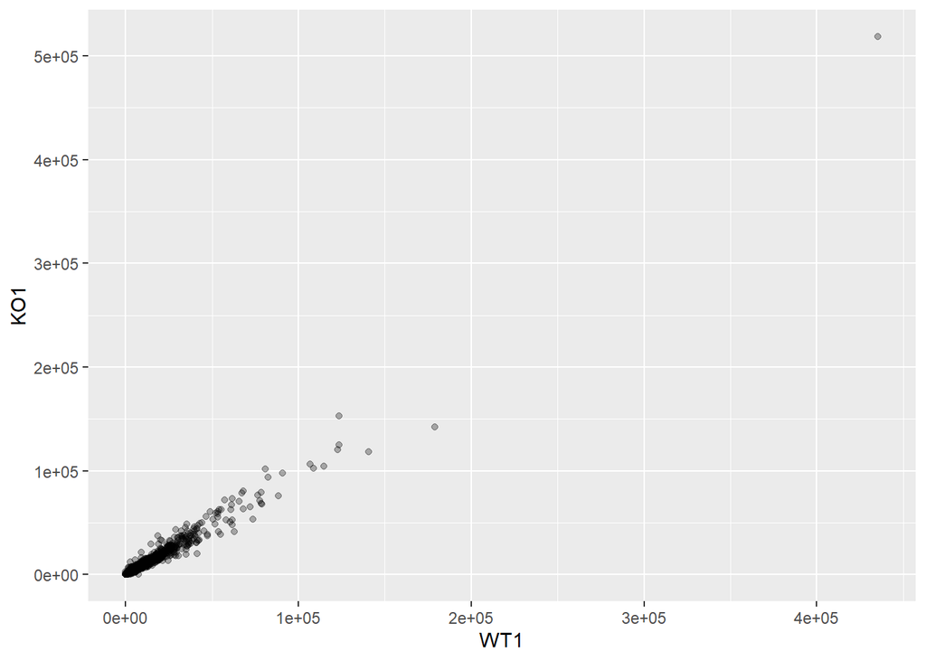

```r
ggplot(ESC_p53_1, aes(WT1, KO1))+
  geom_point(size = 1.5,
             alpha = 0.3)
```

## EDA Graph

BEGIN TO EXPLORE HOW YOU MIGHT PLOT IT. OK TO SHOW YOUR FAILURES, OR HALF-FINISHED PRODUCTS HERE.

Difference was not so clear between these cells, so I added the log2 fold changes.

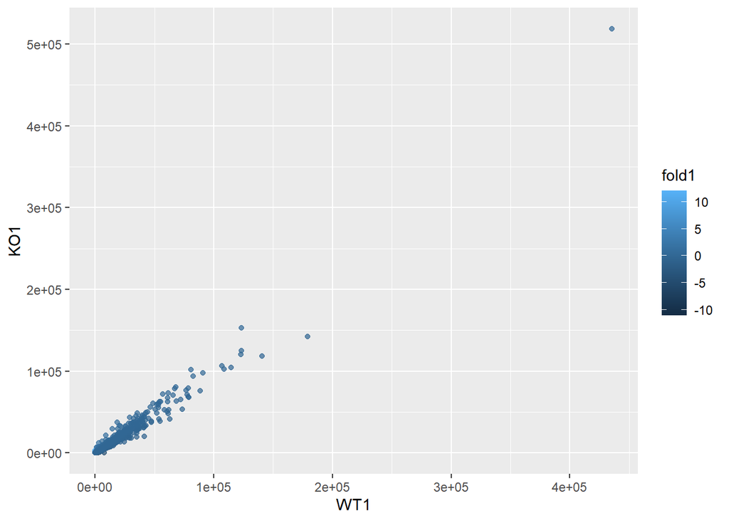

```r
ggplot(ESC_p53_1, aes(WT1, KO1))+
    geom_point(aes(colour = fold1),
             size = 1.5,
             alpha = 0.7)
```

## Final Graph

SET UP THE BIG FINALE

It is not very clear because the dots were condensed and overlapped in small places. Therefore, I changed to a logarithmic scale. I also changed the title and legend to improve the appearance. Rainbow colors are also used to make the changes in the log2 fold more obvious.

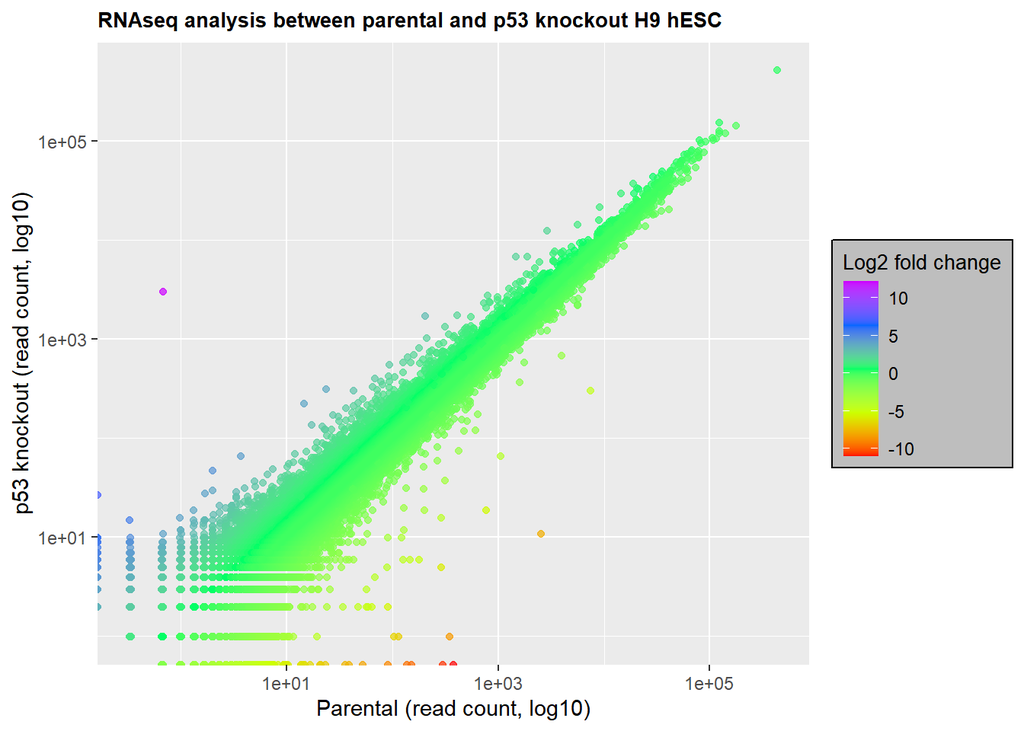

```r
ggplot(ESC_p53, aes(WT1, KO1))+
    geom_point(aes(colour = fold1),
             size = 1.5,
             alpha = 0.7)+
  scale_color_gradientn(colours = rainbow(5))+
  scale_x_continuous(trans = "log10")+
  scale_y_continuous(trans = "log10")+

labs(x = "Parental (read count, log10)",
       y = "p53 knockout (read count, log10)",
       title = "RNAseq analysis between parental and p53 knockout H9 hESC", color = "Log2 fold change")+
theme(plot.title = element_text(face = "bold", size = 10),
     legend.background = element_rect(fill="gray", colour="black"),
     legend.position = "right", legend.title = element_text(size=10))
```

## Conclusions

Although majority of gene expression was not changed by p53 knockout, I saw several genes were either induced or repressed by p53. p53 is known to induce and repress genes depending on gene types. However, this plot shows that there are more p53-inducible genes than p53-repressible genes. There are several genes induced by p53, ranging from almost zero to 5-30 fold or more, which is quite interesting.

## Prioritized follow-up studies

WHAT WOULD YOU DO TO FOLLOW-UP?

I like to analyze other 6 KO clones and combine the results to avoid clonal differences due to CRISPR knockout. I also try to make heat map, volcano plot, and venn diagram etc.

## Acknolwedgements

SHOUT OUTS FOR PACKAGES, INSPIRATION, CLASSMATES, OR EVEN Y0UR INSTRUCTORS! ;]

This was a great class, and I learned a lot. Thank you very much, Matthew!

```r
#You can remove an item from sessionInfo(), which is a list with a class attribute, by printing the resulting object omitting one of the list items (omitted list of packages installed, but not loaded)
```